# INTERACTIVE DASHBOARDS WITH SHINY

Robert Mitchell | @robertmitchellv  
2018-12-10

### ABOUT ME

[figure not shown]

- I work at Skid Row Housing Trust as a data analyst
- (I'll just refer to it as SRHT from now on)
- I have been working in this role for around three years
- I am self taught as a programmer/analyst
- Background in philosophy, comp lit, french, information science

### A BIT ABOUT SRHT

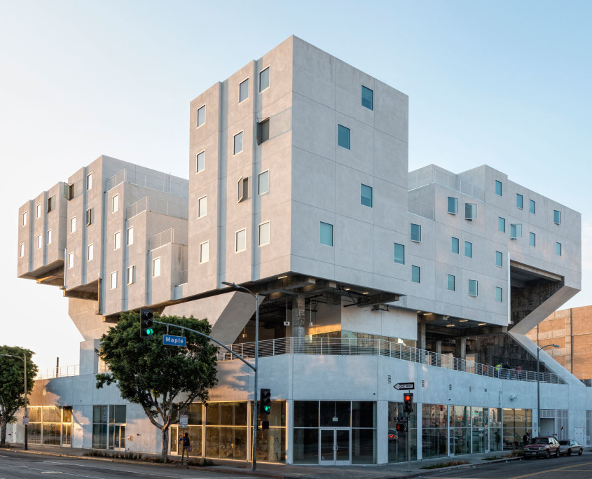

- We do three things:
  1. Develop affordable housing; specifically permanent supportive housing
  2. Provide supportive services to the residents of our affordable housing projects
  3. Have an affiliate manage the properties, repairs, et cetera

### A BIT ABOUT SRHT

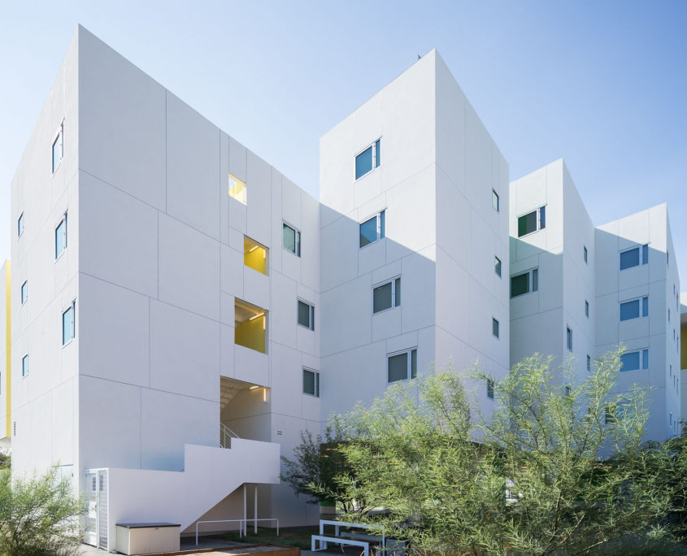

- We believe in the Housing First model
- We believe in Harm Reduction
- This is pretty much industry standard for the most part

### WHAT I WANT TO COVER

- UI ➡️ server ➡️ user feedback loop
- The different ways your `shiny` app can *be* interactive
- The different ways your `shiny` app can *look*
  - The libraries associated with these efforts
- How you can dip your toe into this kind work if phrases like **deploy my application** are scary using `flexdashboard` instead of `shiny`
- *Briefly* touch on the improvements to the `shiny` framework, e.g., `async` and how you can make it scale (things to think about for later)

### WHO THIS TALK IS FOR

- People who have been learning R for a little while and are curious about they can put their work online
- You've maybe done a `shiny` tutorial before but didn't finish it

[figure not shown]

### WHO THIS TALK IS FOR

[figure not shown]

- You're eager to learn how some of this works but may not have time to put it to use yet
- You're really just dipping your toe into this and want to get an idea into how it works

### WHAT I HOPE FOR YOU AFTER

- It's ok if you walk away from this still not sure how you're going to build your `shiny` application–writing code is hard and you should know it takes non-software engineers a while to wrap their minds around things like this
- This is definitely my experience

[figure not shown]

### WHAT I HOPE FOR YOU AFTER

[figure not shown]

- The confidence to go home, read through some documentation and just try to start putting things together!
- You won't learn until you try!

### WHY SHINY?

[figure not shown]

### WHY SHINY?

- You can leverage the work you have already done in R to accomplish something you would normally need to learn JavaScript, Ruby, Python, PHP, or something else to accomplish
- The same way that you would create a visualization for an `rmarkdown` report can be repurposed for another medium
  - This is *especially* true of `flexdashboard`, which you should *always* use in the event a `shiny` application is unnecessarily adding complexity to your work! (we'll talk about this more later)

### FEEDBACK LOOP?

- I'm talking about the ways in which your user *clicks* and explores your dashboard's **user interface** (UI)
- Which then *triggers* code in your `server` code to run
- Which then *returns* **output** back to your **input**
- So your user can get what they need

[figure not shown]